# Nodal by Nature

alex@socialbicycles

March 22, 2017

In transportation planning, a node is an intersection of transportation lines. In the station-based bikeshare model, some stations capture a greater share of trips than others and play a more central role as nodes. We took the top 5 most frequently visited stations in the Citibike network and using trip data from 2016, tracked how long it took on average before a bike visited at least one of the stations. Each unique bikeid was treated as a separate entity and tracked - allowing us to determine the exact amount of time that lapsed in between nodal station visits for each bike. We subset the data by bikeids that were active at least once during every month of the year, which turned out to be about half of the total fleet (5,087 bikes out of 10,581 total or 48.1%). These bikes took an average of **3.77 trips per day**.

The top 5 Citibike stations by usage

| Station | Trips Started |
| --- | --- |
| Pershing Square North | **159365** |
| W 21 St & 6 Ave | **107639** |
| E 17 St & Broadway | **105591** |
| Broadway & E 22 St | **102901** |
| West St & Chambers St | **102851** |

```r
#popstations are 519, 435, 497, 426, 402


citibike_stations <- read.csv("stations.csv")
colnames(citibike_stations)[5] <- "lat"
colnames(citibike_stations)[6] <- "lon"
colnames(citibike_stations)[2] <- "id"

top5 <- citibike_stations[citibike_stations$id == 519 | citibike_stations$id == 435 | citibike_stations$id == 497 | citibike_stations$id == 426 | citibike_stations$id == 402,]



coordinates(citibike_stations) <- ~lon + lat
proj4string(citibike_stations) <- proj4string(nyc_bndry)

coordinates(top5) <- ~lon + lat
proj4string(top5) <- proj4string(nyc_bndry)



cols <- colorRampPalette(brewer.pal(9, "Greys"))

nyc <- mapview(nyc_bndry, alpha = .8, color = "grey", fill = "none", legend = mapviewGetOption("legend"),  map.types = c("CartoDB.DarkMatter", "OpenStreetMap.DE"))

points <- mapview(citibike_stations, cex = .85, fillColor = "none", alpha.regions = .9)
top5 <- mapview(top5, fillColor = "green", color = "green", cex = 5)

nyc + points + top5
```

[interactive chart not shown]

- It took bikes an average of **4,789 minutes** or **3 days 7 hours 49 minutes** to reach a top 5 station in 2016.

New York [Neighborhood Tabulation Areas](https://www1.nyc.gov/site/planning/data-maps/open-data/dwn-nynta.page) (NYNTAs) were originally created to project populations at a small area level. These areas were used to divide the city into sections. The most frequently visited stations per tabulation area were identified and used for further analysis to determine how often bikes visited nodes over the entire system area. It was found that bikes took less time to visit at least one of top 5 stations systemwide than at least one of the 20 most frequently visited stations by NYNTA.

```r
citibike_stations <- read.csv("stations.csv")
colnames(citibike_stations)[5] <- "lat"
colnames(citibike_stations)[6] <- "lon"
colnames(citibike_stations)[2] <- "id"

coordinates(citibike_stations) <- ~lon + lat
proj4string(citibike_stations) <- proj4string(nyc_bndry)


stations_subset1 <- citibike_stations[nyc_bndry[nyc_bndry$NTAName == "East Village",], ]
eastVillage <- stations_subset1$id
stations_subset2 <- citibike_stations[nyc_bndry[nyc_bndry$NTAName == "Chinatown",], ]
chinatown <- stations_subset2$id
stations_subset3 <- citibike_stations[nyc_bndry[nyc_bndry$NTAName == "SoHo-TriBeCa-Civic Center-Little Italy",], ]
soho <- stations_subset3$id
stations_subset4 <- citibike_stations[nyc_bndry[nyc_bndry$NTAName == "Battery Park City-Lower Manhattan",], ]
BPC_lowerMan <- stations_subset4$id
stations_subset5 <- citibike_stations[nyc_bndry[nyc_bndry$NTAName == "West Village",], ]
westVillage <- stations_subset5$id
stations_subset6 <- citibike_stations[nyc_bndry[nyc_bndry$NTAName == "Gramercy",], ]
gramercy <- stations_subset6$id
stations_subset7 <- citibike_stations[nyc_bndry[nyc_bndry$NTAName == "Hudson Yards-Chelsea-Flatiron-Union Square",], ]
chelseaFlatiron <- stations_subset7$id
stations_subset8 <- citibike_stations[nyc_bndry[nyc_bndry$NTAName == "Midtown-Midtown South",], ]
midtown <- stations_subset8$id
stations_subset9 <- citibike_stations[nyc_bndry[nyc_bndry$NTAName == "Murray Hill-Kips Bay",], ]
kipsBay <- stations_subset9$id
stations_subset10 <- citibike_stations[nyc_bndry[nyc_bndry$NTAName == "Clinton",], ]
clinton <- stations_subset10$id
stations_subset11 <- citibike_stations[nyc_bndry[nyc_bndry$NTAName == "Lincoln Square",], ]
lincolnSquare <- stations_subset11$id
stations_subset12 <- citibike_stations[nyc_bndry[nyc_bndry$NTAName == "Upper East Side-Carnegie Hill",], ]
upperEast <- stations_subset12$id
stations_subset13 <- citibike_stations[nyc_bndry[nyc_bndry$NTAName == "Upper West Side",], ]
upperWest <- stations_subset13$id
stations_subset14 <- citibike_stations[nyc_bndry[nyc_bndry$NTAName == "Yorkville",], ]
yorkville <- stations_subset14$id
stations_subset15 <- citibike_stations[nyc_bndry[nyc_bndry$NTAName == "Lenox Hill-Roosevelt Island",], ]
lenoxHill <- stations_subset15$id
stations_subset16 <- citibike_stations[nyc_bndry[nyc_bndry$NTAName == "DUMBO-Vinegar Hill-Downtown Brooklyn-Boerum Hill",], ]
downBkln <- stations_subset16$id
stations_subset17 <- citibike_stations[nyc_bndry[nyc_bndry$NTAName == "North Side-South Side",], ]
williamsburg <- stations_subset17$id
stations_subset18 <- citibike_stations[nyc_bndry[nyc_bndry$NTAName == "Park Slope-Gowanus",], ]
parkSlope <- stations_subset18$id
stations_subset19 <- citibike_stations[nyc_bndry[nyc_bndry$NTAName == "Fort Greene",], ]
fortGreene<- stations_subset19$id
stations_subset20 <- citibike_stations[nyc_bndry[nyc_bndry$NTAName == "Bedford",], ]
bedford <- stations_subset20$id




station_key <-read.csv("stations.csv")

popStations <- as.data.frame(table(citi$`start station id`))
popStations <- popStations[order(-popStations$Freq),]
rownames(popStations) <- 1:nrow(popStations)


selectedRows <- (popStations$Var1 %in% eastVillage)
eastVillage_reduce <- popStations[selectedRows,][1,]
eastVillage_reduce <- merge(eastVillage_reduce, station_key, by.x = "Var1", by.y = "data.stations.station_id")
eastVillage_reduce <- eastVillage_reduce[, -c(3:5)]
colnames(eastVillage_reduce)[3:4] <- c("lat", "lon")
coordinates(eastVillage_reduce) <- ~lon + lat
proj4string(eastVillage_reduce) <- proj4string(nyc_bndry)


selectedRows <- (popStations$Var1 %in% chinatown)
chinatown_reduce <- popStations[selectedRows,][1,]
chinatown_reduce <- merge(chinatown_reduce, station_key, by.x = "Var1", by.y = "data.stations.station_id")
chinatown_reduce <- chinatown_reduce[, -c(3:5)]
colnames(chinatown_reduce)[3:4] <- c("lat", "lon")
coordinates(chinatown_reduce) <- ~lon + lat
proj4string(chinatown_reduce) <- proj4string(nyc_bndry)


selectedRows <- (popStations$Var1 %in% soho)
soho_reduce <- popStations[selectedRows,][1,]
soho_reduce <- merge(soho_reduce, station_key, by.x = "Var1", by.y = "data.stations.station_id")
soho_reduce <- soho_reduce[, -c(3:5)]
colnames(soho_reduce)[3:4] <- c("lat", "lon")
coordinates(soho_reduce) <- ~lon + lat
proj4string(soho_reduce) <- proj4string(nyc_bndry)


selectedRows <- (popStations$Var1 %in% BPC_lowerMan)
BPC_lowerMan_reduce <- popStations[selectedRows,][1,]
BPC_lowerMan_reduce <- merge(BPC_lowerMan_reduce, station_key, by.x = "Var1", by.y = "data.stations.station_id")
BPC_lowerMan_reduce <- BPC_lowerMan_reduce[, -c(3:5)]
colnames(BPC_lowerMan_reduce)[3:4] <- c("lat", "lon")
coordinates(BPC_lowerMan_reduce) <- ~lon + lat
proj4string(BPC_lowerMan_reduce) <- proj4string(nyc_bndry)

selectedRows <- (popStations$Var1 %in% westVillage)
westVillage_reduce <- popStations[selectedRows,][1,]
westVillage_reduce <- merge(westVillage_reduce, station_key, by.x = "Var1", by.y = "data.stations.station_id")
westVillage_reduce <- westVillage_reduce[, -c(3:5)]
colnames(westVillage_reduce)[3:4] <- c("lat", "lon")
coordinates(westVillage_reduce) <- ~lon + lat
proj4string(westVillage_reduce) <- proj4string(nyc_bndry)

selectedRows <- (popStations$Var1 %in% gramercy)
gramercy_reduce <- popStations[selectedRows,][1,]
gramercy_reduce <- merge(gramercy_reduce, station_key, by.x = "Var1", by.y = "data.stations.station_id")
gramercy_reduce <- gramercy_reduce[, -c(3:5)]
colnames(gramercy_reduce)[3:4] <- c("lat", "lon")
coordinates(gramercy_reduce) <- ~lon + lat
proj4string(gramercy_reduce) <- proj4string(nyc_bndry)

selectedRows <- (popStations$Var1 %in% chelseaFlatiron)
chelseaFlatiron_reduce <- popStations[selectedRows,][1,]
chelseaFlatiron_reduce <- merge(chelseaFlatiron_reduce, station_key, by.x = "Var1", by.y = "data.stations.station_id")
chelseaFlatiron_reduce <- chelseaFlatiron_reduce[, -c(3:5)]
colnames(chelseaFlatiron_reduce)[3:4] <- c("lat", "lon")
coordinates(chelseaFlatiron_reduce) <- ~lon + lat
proj4string(chelseaFlatiron_reduce) <- proj4string(nyc_bndry)
```

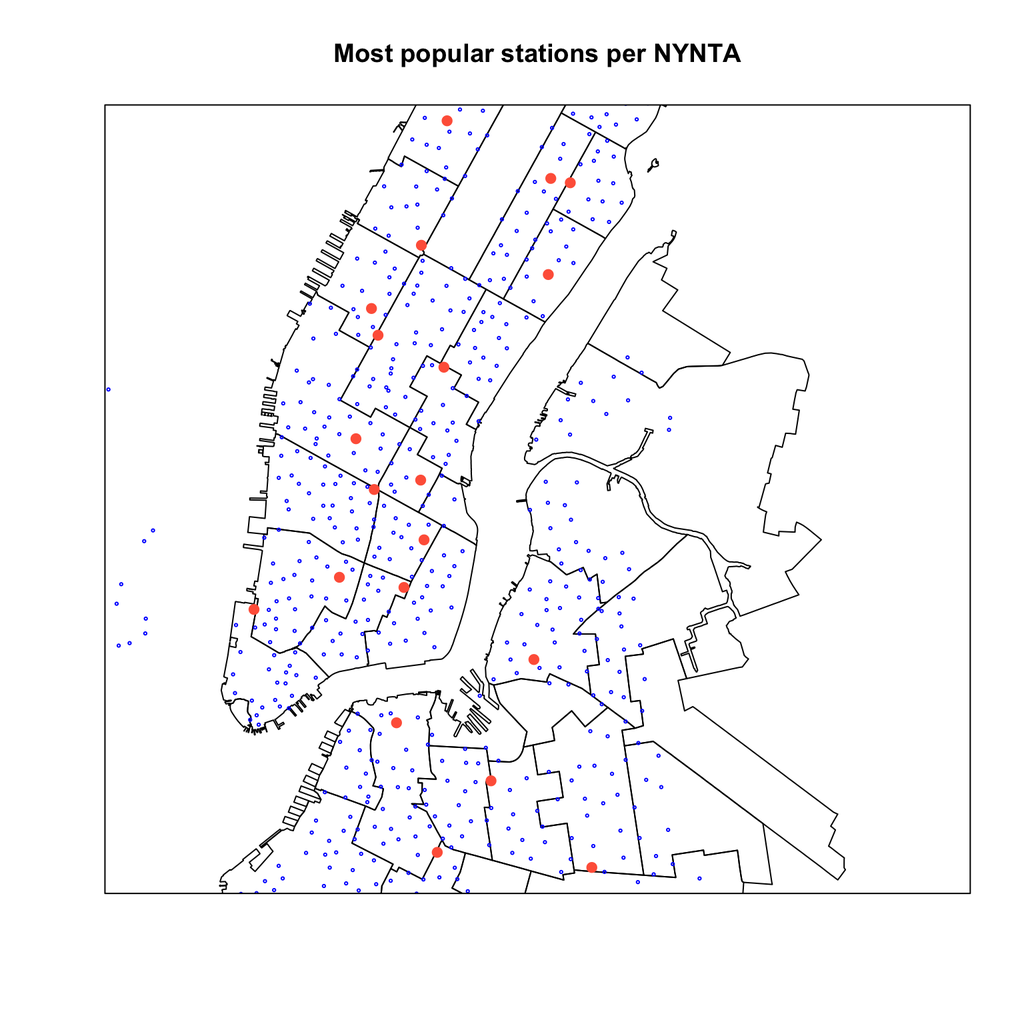

```r
selectedRows <- (popStations$Var1 %in% midtown)
midtown_reduce <- popStations[selectedRows,][1,]
midtown_reduce <- merge(midtown_reduce, station_key, by.x = "Var1", by.y = "data.stations.station_id")
midtown_reduce <- midtown_reduce[, -c(3:5)]
colnames(midtown_reduce)[3:4] <- c("lat", "lon")
coordinates(midtown_reduce) <- ~lon + lat
proj4string(midtown_reduce) <- proj4string(nyc_bndry)

selectedRows <- (popStations$Var1 %in% kipsBay)
kipsBay_reduce <- popStations[selectedRows,][1,]
kipsBay_reduce <- merge(kipsBay_reduce, station_key, by.x = "Var1", by.y = "data.stations.station_id")
kipsBay_reduce <- kipsBay_reduce[, -c(3:5)]
colnames(kipsBay_reduce)[3:4] <- c("lat", "lon")
coordinates(kipsBay_reduce) <- ~lon + lat
proj4string(kipsBay_reduce) <- proj4string(nyc_bndry)

selectedRows <- (popStations$Var1 %in% clinton)
clinton_reduce <- popStations[selectedRows,][1,]
clinton_reduce <- merge(clinton_reduce, station_key, by.x = "Var1", by.y = "data.stations.station_id")
clinton_reduce <- clinton_reduce[, -c(3:5)]
colnames(clinton_reduce)[3:4] <- c("lat", "lon")
coordinates(clinton_reduce) <- ~lon + lat
proj4string(clinton_reduce) <- proj4string(nyc_bndry)

selectedRows <- (popStations$Var1 %in% lincolnSquare)
lincolnSquare_reduce <- popStations[selectedRows,][1,]
lincolnSquare_reduce <- merge(lincolnSquare_reduce, station_key, by.x = "Var1", by.y = "data.stations.station_id")
lincolnSquare_reduce <- lincolnSquare_reduce[, -c(3:5)]
colnames(lincolnSquare_reduce)[3:4] <- c("lat", "lon")
coordinates(lincolnSquare_reduce) <- ~lon + lat
proj4string(lincolnSquare_reduce) <- proj4string(nyc_bndry)

selectedRows <- (popStations$Var1 %in% upperEast)
upperEast_reduce <- popStations[selectedRows,][1,]
upperEast_reduce <- merge(upperEast_reduce, station_key, by.x = "Var1", by.y = "data.stations.station_id")
upperEast_reduce <- upperEast_reduce[, -c(3:5)]
colnames(upperEast_reduce)[3:4] <- c("lat", "lon")
coordinates(upperEast_reduce) <- ~lon + lat
proj4string(upperEast_reduce) <- proj4string(nyc_bndry)

selectedRows <- (popStations$Var1 %in% upperWest)
upperWest_reduce <- popStations[selectedRows,][1,]
upperWest_reduce <- merge(upperWest_reduce, station_key, by.x = "Var1", by.y = "data.stations.station_id")
upperWest_reduce <- upperWest_reduce[, -c(3:5)]
colnames(upperWest_reduce)[3:4] <- c("lat", "lon")
coordinates(upperWest_reduce) <- ~lon + lat
proj4string(upperWest_reduce) <- proj4string(nyc_bndry)

selectedRows <- (popStations$Var1 %in% yorkville)
yorkville_reduce <- popStations[selectedRows,][1,]
yorkville_reduce <- merge(yorkville_reduce, station_key, by.x = "Var1", by.y = "data.stations.station_id")
yorkville_reduce <- yorkville_reduce[, -c(3:5)]
colnames(yorkville_reduce)[3:4] <- c("lat", "lon")
coordinates(yorkville_reduce) <- ~lon + lat
proj4string(yorkville_reduce) <- proj4string(nyc_bndry)

selectedRows <- (popStations$Var1 %in% lenoxHill)
lenoxHill_reduce <- popStations[selectedRows,][1,]
lenoxHill_reduce <- merge(lenoxHill_reduce, station_key, by.x = "Var1", by.y = "data.stations.station_id")
lenoxHill_reduce <- lenoxHill_reduce[, -c(3:5)]
colnames(lenoxHill_reduce)[3:4] <- c("lat", "lon")
coordinates(lenoxHill_reduce) <- ~lon + lat
proj4string(lenoxHill_reduce) <- proj4string(nyc_bndry)

selectedRows <- (popStations$Var1 %in% downBkln)
downBkln_reduce <- popStations[selectedRows,][1,]
downBkln_reduce <- merge(downBkln_reduce, station_key, by.x = "Var1", by.y = "data.stations.station_id")
downBkln_reduce <- downBkln_reduce[, -c(3:5)]
colnames(downBkln_reduce)[3:4] <- c("lat", "lon")
coordinates(downBkln_reduce) <- ~lon + lat
proj4string(downBkln_reduce) <- proj4string(nyc_bndry)

selectedRows <- (popStations$Var1 %in% williamsburg)
williamsburg_reduce <- popStations[selectedRows,][1,]
williamsburg_reduce <- merge(williamsburg_reduce, station_key, by.x = "Var1", by.y = "data.stations.station_id")
williamsburg_reduce <- williamsburg_reduce[, -c(3:5)]
colnames(williamsburg_reduce)[3:4] <- c("lat", "lon")
coordinates(williamsburg_reduce) <- ~lon + lat
proj4string(williamsburg_reduce) <- proj4string(nyc_bndry)

selectedRows <- (popStations$Var1 %in% parkSlope)
parkSlope_reduce <- popStations[selectedRows,][1,]
parkSlope_reduce <- merge(parkSlope_reduce, station_key, by.x = "Var1", by.y = "data.stations.station_id")
parkSlope_reduce <- parkSlope_reduce[, -c(3:5)]
colnames(parkSlope_reduce)[3:4] <- c("lat", "lon")
coordinates(parkSlope_reduce) <- ~lon + lat
proj4string(parkSlope_reduce) <- proj4string(nyc_bndry)

selectedRows <- (popStations$Var1 %in% fortGreene)
fortGreene_reduce <- popStations[selectedRows,][1,]
fortGreene_reduce <- merge(fortGreene_reduce, station_key, by.x = "Var1", by.y = "data.stations.station_id")
fortGreene_reduce <- fortGreene_reduce[, -c(3:5)]
colnames(fortGreene_reduce)[3:4] <- c("lat", "lon")
coordinates(fortGreene_reduce) <- ~lon + lat
proj4string(fortGreene_reduce) <- proj4string(nyc_bndry)

selectedRows <- (popStations$Var1 %in% bedford)
bedford_reduce <- popStations[selectedRows,][1,]
bedford_reduce <- merge(bedford_reduce, station_key, by.x = "Var1", by.y = "data.stations.station_id")
bedford_reduce <- bedford_reduce[, -c(3:5)]
colnames(bedford_reduce)[3:4] <- c("lat", "lon")
coordinates(bedford_reduce) <- ~lon + lat
proj4string(bedford_reduce) <- proj4string(nyc_bndry)



#Subset by neighborhoods

plot(nyc_bndry, alpha = .9, xlim=c(-73.96995, -73.95042), ylim=c(40.68144, 40.7849), main = "Most popular stations per NYNTA")
plot(citibike_stations, pch =1, col = "blue", add = TRUE, alpha = 0.7, cex = .3)
plot(eastVillage_reduce, col = "tomato", pch = 19, add = TRUE)
plot(chinatown_reduce, col = "tomato", pch = 19, add = TRUE)
plot(soho_reduce, col = "tomato", pch = 19, add = TRUE)
plot(BPC_lowerMan_reduce, col = "tomato", pch = 19, add = TRUE)
plot(westVillage_reduce, col = "tomato", pch = 19, add = TRUE)
plot(gramercy_reduce, col = "tomato", pch = 19, add = TRUE)
plot(chelseaFlatiron_reduce, col = "tomato", pch = 19, add = TRUE)
plot(midtown_reduce, col = "tomato", pch = 19, add = TRUE)
plot(kipsBay_reduce, col = "tomato", pch = 19, add = TRUE)
plot(clinton_reduce, col = "tomato", pch = 19, add = TRUE)
plot(lincolnSquare_reduce, col = "tomato", pch = 19, add = TRUE)
plot(upperEast_reduce, col = "tomato", pch = 19, add = TRUE)
plot(upperWest_reduce, col = "tomato", pch = 19, add = TRUE)
plot(yorkville_reduce, col = "tomato", pch = 19, add = TRUE)
plot(lenoxHill_reduce, col = "tomato", pch = 19, add = TRUE)
plot(downBkln_reduce, col = "tomato", pch = 19, add = TRUE)
plot(williamsburg_reduce, col = "tomato", pch = 19, add = TRUE)
plot(parkSlope_reduce, col = "tomato", pch = 19, add = TRUE)
plot(fortGreene_reduce, col = "tomato", pch = 19, add = TRUE)
plot(bedford_reduce, col = "tomato", pch = 19, add = TRUE)
box(col = "black")
```

- It took bikes an average of **7,662 minutes** or **5 days 7 hours 42 minutes** to reach a top station by NYNTA subdivision in 2016.

```r
par(mfrow=c(5,4))


plot(stations_subset1, main = "East Village", pch =1, col = "blue" )
plot(nyc_bndry, add = TRUE)
plot(eastVillage_reduce, col = "red", pch = 19, add = TRUE, cex = 2)
box(col = "black")


plot(stations_subset2, main = "Chinatown" , pch =1, col = "blue" )
plot(nyc_bndry, add = TRUE)
plot(chinatown_reduce, col = "red", pch = 19, add = TRUE, cex = 2)
box(col = "black")

plot(stations_subset3, main = "SoHo / Tribeca" , pch =1, col = "blue" )
plot(nyc_bndry, add = TRUE)
plot(soho_reduce, col = "red", pch = 19, add = TRUE, cex = 2)
box(col = "black")


plot(stations_subset4, main = "Lower Manhattan" , pch =1, col = "blue" )
plot(nyc_bndry, add = TRUE)
plot(BPC_lowerMan_reduce, col = "red", pch = 19, add = TRUE, cex = 2)
box(col = "black")

plot(stations_subset5, main = "West Village" , pch =1, col = "blue" )
plot(nyc_bndry, add = TRUE)
plot(westVillage_reduce, col = "red", pch = 19, add = TRUE, cex = 2)
box(col = "black")

plot(stations_subset6, main = "Gramercy", pch =1, col = "blue")
plot(nyc_bndry, add = TRUE)
plot(gramercy_reduce, col = "red", pch = 19, add = TRUE, cex = 2)
box(col = "black")

plot(stations_subset7, main = "Chelsea / Flatiron" , pch =1, col = "blue" )
plot(nyc_bndry, add = TRUE)
plot(chelseaFlatiron_reduce, col = "red", pch = 19, add = TRUE, cex = 2)
box(col = "black")

plot(stations_subset8, main = "Midtown", pch =1, col = "blue")
plot(nyc_bndry, add = TRUE)
plot(midtown_reduce, col = "red", pch = 19, add = TRUE, cex = 2)
box(col = "black")

plot(stations_subset9, main = "Kips Bay", pch =1, col = "blue")
plot(nyc_bndry, add = TRUE)
plot(kipsBay_reduce, col = "red", pch = 19, add = TRUE, cex = 2)
box(col = "black")

plot(stations_subset10, main = "Clinton", pch =1, col = "blue")
plot(nyc_bndry, add = TRUE)
plot(clinton_reduce, col = "red", pch = 19, add = TRUE, cex = 2)
box(col = "black")


plot(stations_subset11, main = "Lincoln Sq", pch =1, col = "blue")
plot(nyc_bndry, add = TRUE)
plot(lincolnSquare_reduce, col = "red", pch = 19, add = TRUE, cex = 2)
box(col = "black")

plot(stations_subset12, main = "Upper East Side", pch =1, col = "blue")
plot(nyc_bndry, add = TRUE)
plot(upperEast_reduce, col = "red", pch = 19, add = TRUE, cex = 2)
box(col = "black")

plot(stations_subset13, main = "Upper West Side", pch =1, col = "blue")
plot(nyc_bndry, add = TRUE)
plot(upperWest_reduce, col = "red", pch = 19, add = TRUE, cex = 2)
box(col = "black")

plot(stations_subset14, main = "Yorkville", pch =1, col = "blue")
plot(nyc_bndry, add = TRUE)
plot(yorkville_reduce, col = "red", pch = 19, add = TRUE, cex = 2)
box(col = "black")


plot(stations_subset15, main = "Lenox Hill", pch =1, col = "blue")
plot(nyc_bndry, add = TRUE)
plot(lenoxHill_reduce, col = "red", pch = 19, add = TRUE, cex = 2)
box(col = "black")

plot(stations_subset16, main = "Downtown Brooklyn", pch =1, col = "blue")
plot(nyc_bndry, add = TRUE)
plot(downBkln_reduce, col = "red", pch = 19, add = TRUE, cex = 2)
box(col = "black")

plot(stations_subset17, main = "Williamsburg", pch =1, col = "blue")
plot(nyc_bndry, add = TRUE)
plot(williamsburg_reduce, col = "red", pch = 19, add = TRUE, cex = 2)
box(col = "black")

plot(stations_subset18, main = "Park Slope", pch =1, col = "blue")
plot(nyc_bndry, add = TRUE)
plot(parkSlope_reduce, col = "red", pch = 19, add = TRUE, cex = 2)
box(col = "black")

plot(stations_subset19, main = "Fort Greene", pch =1, col = "blue")
plot(nyc_bndry, add = TRUE)
plot(fortGreene_reduce, col = "red", pch = 19, add = TRUE, cex = 2)
box(col = "black")

plot(stations_subset20, main = "Bedford", pch =1, col = "blue")
plot(nyc_bndry, add = TRUE)
plot(bedford_reduce, col = "red", pch = 19, add = TRUE, cex = 2)
box(col = "black")
```

[output not shown]

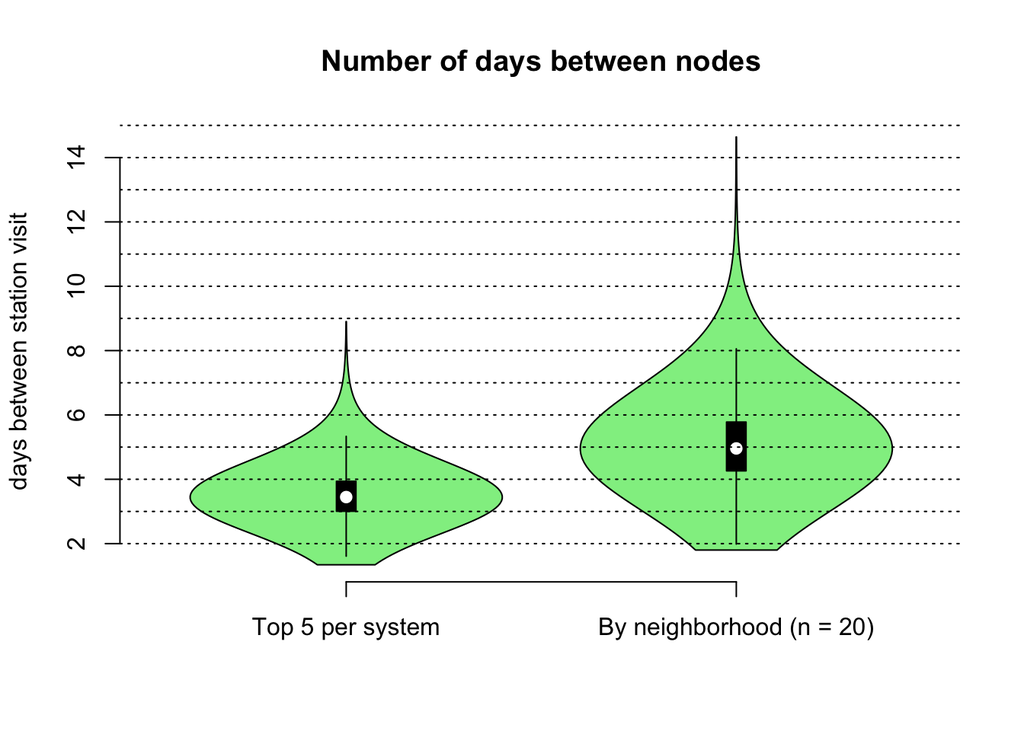

```r
#now merge the spatial points into something

new_ids <- c(eastVillage_reduce$Var1, chinatown_reduce$Var1, soho_reduce$Var1, BPC_lowerMan_reduce$Var1,
             westVillage_reduce$Var1, gramercy_reduce$Var1, chelseaFlatiron_reduce$Var1, midtown_reduce$Var1,
             kipsBay_reduce$Var1, clinton_reduce$Var1, lincolnSquare_reduce$Var1, upperEast_reduce$Var1,
             upperWest_reduce$Var1, yorkville_reduce$Var1, lenoxHill_reduce$Var1, downBkln_reduce$Var1,
             williamsburg_reduce$Var1, parkSlope_reduce$Var1, fortGreene_reduce$Var1, bedford_reduce$Var1)



selectedRows <- (citi$bikeid %in% ids)
citi_reduce <- citi[selectedRows,]

#use original data to find most popular stations and order by decreasing frequency

popStations <- as.data.frame(table(citi$`start station id`))
popStations <- popStations[order(-popStations$Freq),]
popStations <- head(popStations, n = 5)
popStations <- as.integer(as.numeric(as.vector(popStations$Var1)))


#subset citi_reduce by most popular stations that were either in the start.station.id or end.station.id

selectedRows <- (citi_reduce$`start station id` %in%  new_ids | citi_reduce$`end station id` %in% new_ids)
citi_reduce <- citi_reduce[selectedRows,]

#take trips that were less than 10 hours in duration
citi_reduce <- citi_reduce[citi_reduce$tripduration < 36000,]

#reorder
citi_reduce <- citi_reduce[ with(citi_reduce, order(citi_reduce$bikeid, citi_reduce$starttime)), ]

#take differences of times

b= lead(citi_reduce$starttime)
citi_reduce$diff  = c(NA, ifelse(citi_reduce$bikeid[-nrow(citi_reduce)] == lead(citi_reduce$bikeid)[-nrow(citi_reduce)], difftime(citi_reduce$starttime[-nrow(citi_reduce)], b[-nrow(citi_reduce)], units = "mins"), NA))

#remove NA values and take the global mean
citi_reduce <- citi_reduce %>% drop_na(diff)
citi_reduce <- citi_reduce[citi_reduce$month != 0,]

##do not use for now
per_bike_20 <- aggregate(diff ~ bikeid, citi_reduce, mean)

par(bty = 'n')
vioplot((-per_bike_5$diff/60)/24, (-per_bike_20$diff)/60/24, col = "light green", names = c("Top 5 per system", "By neighborhood (n = 20)"))
title(main = "Number of days between nodes", ylab = "days between station visit")
abline(h=2:16, col="black", lty=3)
```

**Quantiles**

50% of bikes visited the top 5 stations in the space of **3-4 days** and the 20 NYNTA nodes in the space of **4 1/4 - 5 3/4 days**. The black box in the boxplot above represents the middle 50% of the data. The box edges are the 25th and 75th percentile.

*Top 5*

```r
#quantiles of top 5
pander(quantile((-per_bike_5$diff/60)/24),  caption = attr(quantile((-per_bike_5$diff/60)/24),"Top 5"), title = "hello")
```

| 0% | 25% | 50% | 75% | 100% |
| --- | --- | --- | --- | --- |
| 1.343 | 3.006 | 3.447 | 3.937 | 8.901 |

*NYNTA 20*

```r
#quantiles of n = 20
pander(quantile((-per_bike_20$diff/60)/24), caption = "Top NYTNA")
```

| 0% | 25% | 50% | 75% | 100% |
| --- | --- | --- | --- | --- |
| 1.8 | 4.262 | 4.959 | 5.779 | 14.64 |

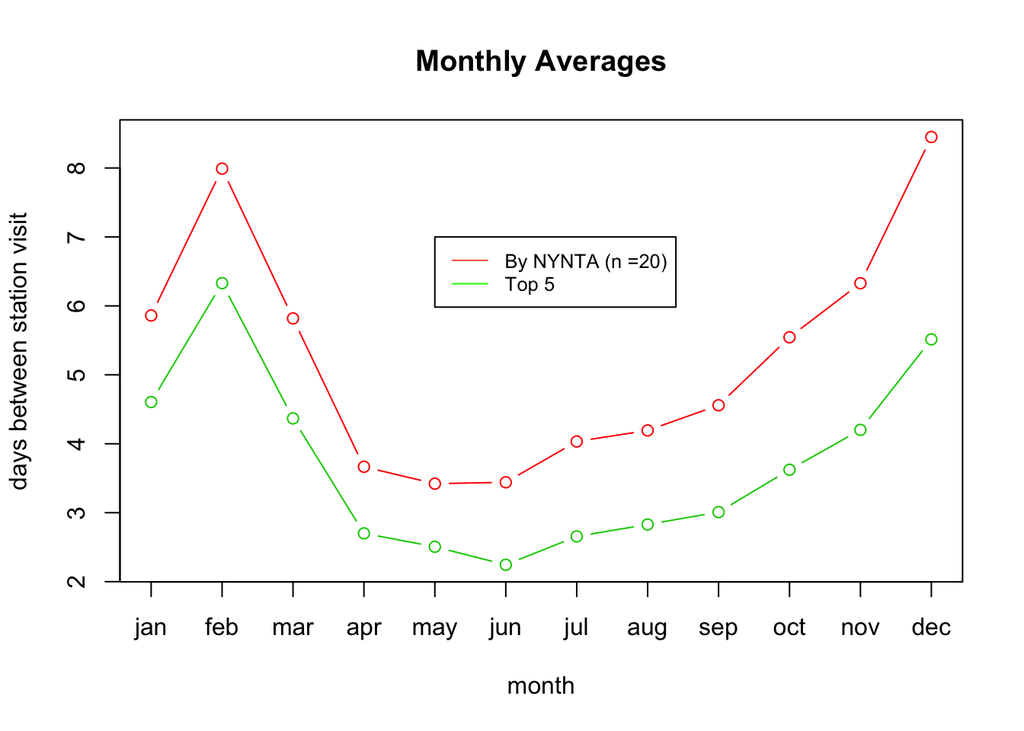

```r
yrange = range(c((plotA$`-diff`/60/24),aggregate((-diff/60)/24 ~ month, citi_reduce, mean)[2]))

plot(aggregate((-diff/60)/24 ~ month, citi_reduce, mean),type="b",col=2, ylab = "days between station visit", ylim = yrange, xaxt = "n", main = "Monthly Averages")
axis(side = 1, at = c(1,2, 3, 4, 5, 6, 7, 8, 9, 10, 11, 12), labels = c("jan", "feb",
     "mar", "apr", "may", "jun", "jul", "aug", "sep", "oct", "nov", "dec"))
par(new = TRUE)
plot(plotA$`-diff`/60/24,type="b", axes = F,col=3, xlab = "", ylab = "", ylim = yrange)
legend(5,7, legend = c("By NYNTA (n =20)", "Top 5"), lty=c(1,1), lwd=c(1,1),col=c("tomato","green"), cex=0.8)
```

**Conclusions**

Tracking all bike movements in New York shows that bikes pass more frequently through the top 5 stations systemwide than they do the top stations per neighborhood. This shows a highly centralized system.

### San Francisco

The same analysis was applied to Bay Area Bikeshare, which had a fleet of **625 bikes** from **09/01/2015 - 08/31/2016**. More than half of the total fleet (387 bikes or 62%) were active for every month of the study period and those bikes took an average of **1.84 trips per day**.

```r
setwd("~/Downloads/Global Bikeshares/babs")

babs <- read_csv("201608_trip_data.csv")

babs <- as.data.frame(babs)

babs$`Start Date`<- as.POSIXct(strptime(babs$`Start Date`, format = '%m/%d/%Y %H:%M'))


babs <- babs %>% drop_na(`Start Date`)
babs$month <- month(babs$`Start Date`)


#find bikeids that were active every month

mat <- babs  %>%
  group_by(`Bike #`, month)%>%
  summarise(sum = n()) %>%
  spread(`Bike #`, sum)

mat <- t(mat)
mat <- as.data.frame(mat[-1,])

#take only bikeids that were active every month
cc <- mat[complete.cases(mat),]

#get the ids of the bikes that were active every month
ids <- as.numeric(row.names(cc))

#subset dataset by active bikeids

selectedRows <- (babs$`Bike #` %in% ids)
babs_reduce <- babs[selectedRows,]


#use original data to find most popular stations and order by decreasing frequency


popStationNames <- as.data.frame(table(babs$`Start Station`))
popStationNames <- popStationNames[order(-popStationNames$Freq),]
colnames(popStationNames)[1] <- "Station"
colnames(popStationNames)[2] <- "Trips Started"

x <- head(popStationNames, n = 5)
rownames(x) <-NULL
pander(x, emphasize.strong.cols = 2)
```

| Station | Trips Started |
| --- | --- |
| San Francisco Caltrain (Townsend at 4th) | **23591** |
| San Francisco Caltrain 2 (330 Townsend) | **22358** |
| Harry Bridges Plaza (Ferry Building) | **16128** |
| 2nd at Townsend | **14099** |
| Steuart at Market | **13693** |

```r
popStations <- as.data.frame(table(babs$`Start Terminal`))
popStations <- popStations[order(-popStations$Freq),]
popStations <- head(popStations, n = 5)
popStations <- as.integer(as.numeric(as.vector(popStations$Var1)))

selectedRows <- (babs_reduce$`Start Terminal` %in% popStations | babs_reduce$`End Terminal` %in% popStations)
babs_reduce <- babs_reduce[selectedRows,]

#take trips that were less than 10 hours in duration
#babs_reduce <- babs_reduce[babs_reduce$tripduration < 36000,]

#reorder
babs_reduce <- babs_reduce[ with(babs_reduce, order(babs_reduce$`Bike #`, babs_reduce$`Start Date`)), ]

#take differences of times

b= lead(babs_reduce$`Start Date`)
babs_reduce$diff  = c(NA, ifelse(babs_reduce$`Bike #`[-nrow(babs_reduce)] == lead(babs_reduce$`Bike #`)[-nrow(babs_reduce)], difftime(babs_reduce$`Start Date`[-nrow(babs_reduce)], b[-nrow(babs_reduce)], units = "mins"), NA))

#remove NA values and take the global mean
babs_reduce <- babs_reduce %>% drop_na(diff)
```

```r
proj4string(top5) <- proj4string(nyc_bndry)
proj4string(all) <- proj4string(nyc_bndry)

cols <- colorRampPalette(brewer.pal(9, "Greys"))

top5 <- mapview(top5,  fillColor = "none",  cex = 5,  color = "green")
points <- mapview(all, fillColor = "blue",  map.types = c("CartoDB.DarkMatter", "OpenStreetMap.DE"),color = "blue", cex = .85)

points + top5
```

[interactive chart not shown]

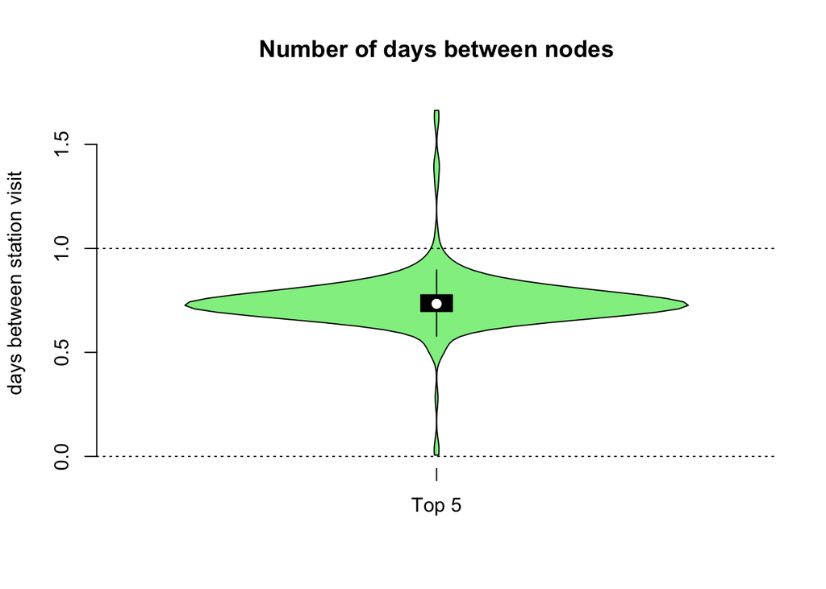

```r
per_bike_5 <- aggregate(diff ~ `Bike #`, babs_reduce, mean)

par(bty = 'n')
vioplot((-per_bike_5$diff/60)/24, col = "light green", names = c("Top 5"))
title(main = "Number of days between nodes", ylab = "days between station visit")
abline(h=0:1, col="black", lty=3)
```

**Quantiles**

50% of bikes visited the top 5 stations in the space of **16.7 - 18.6 hours** . The black box in the boxplot above represents the middle 50% of the data. The box edges are the 25th and 75th percentile.

*Top 5*

```r
#quantiles of top 5
pander(quantile(-per_bike_5$diff,  caption = attr(quantile((-per_bike_5$diff/60)/24),"Top 5"), title = "hello"))
```

| 0% | 25% | 50% | 75% | 100% |
| --- | --- | --- | --- | --- |
| 9 | 1004 | 1057 | 1118 | 2396 |

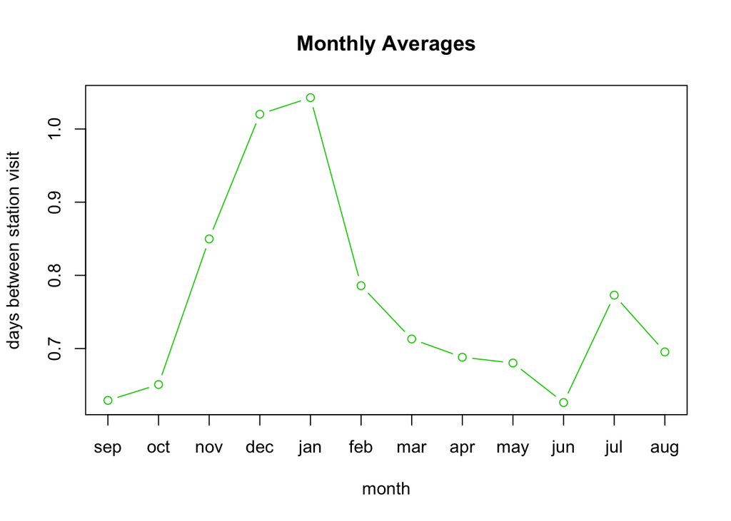

```r
x <- aggregate((-diff/60)/24 ~ month, babs_reduce, mean)
colnames(x)[2] <- "days"
x$month  = factor(x$month, levels=c(9, 10, 11, 12, 1, 2, 3, 4, 5, 6, 7, 8), ordered = TRUE)
x <- x[order(x$month),]


labels <- factor(c("sep", "oct", "nov", "dec", "jan", "feb", "mar", "apr", "may", "jun", "jul", "aug"),levels=c("sep", "oct", "nov", "dec", "jan", "feb", "mar", "apr", "may", "jun", "jul", "aug"))
labels <- factor(labels, levels=c("sep", "oct", "nov", "dec", "jan", "feb", "mar", "apr", "may", "jun", "jul", "aug"))


plot(x$days, type="b",col=3, ylab = "days between station visit", xlab = "month", xaxt = "n", main = "Monthly Averages")
axis(side = 1, at = c(1, 2, 3, 4, 5, 6, 7, 8, 9, 10, 11, 12), labels = labels)
```

**Conclusions**

Tracking all bike movements in San Francisco shows that bikes pass far more frequently through the top 5 stations systemwide tthan they do in New York City. This shows a highly centralized system - but also one that is much smaller than Citibike in terms of system area and number of bikes. It is worth noting that although the Bay Area Bike Share is split between downtown San Francisco and San Jose, and all of the top 5 stations are are located in downtown SF.